# Análisis de Idoneidad y Retención de Talento TI

Gutierrez Fernandez, Jesus Osmar y Marcelo Porcayo, Tonancy Lizahaya

23 de octubre de 2025

# The challenge: Finding the Needle in the Haystack

The tech talent market is vast. Recruiters spend countless hours sifting through profiles, unsure of who is actively looking for a new opportunity. This traditional approach is slow, expensive, and inefficient. We asked a critical question: **Can we use data science to identify the candidates most likely to be open to a new offer?**

The answer is yes. By analyzing over 19,000 candidate profiles, we’ve moved beyond guesswork and built a predictive tool that empowers a smarter, faster, and more effective talent acquisition strategy.

## The key finding: Not all talent behaves the same.

Our analysis revealed that a candidate’s decision to seek a new job is not random; rather, it is strongly linked to their professional profile. We identified four distinct talent segments.

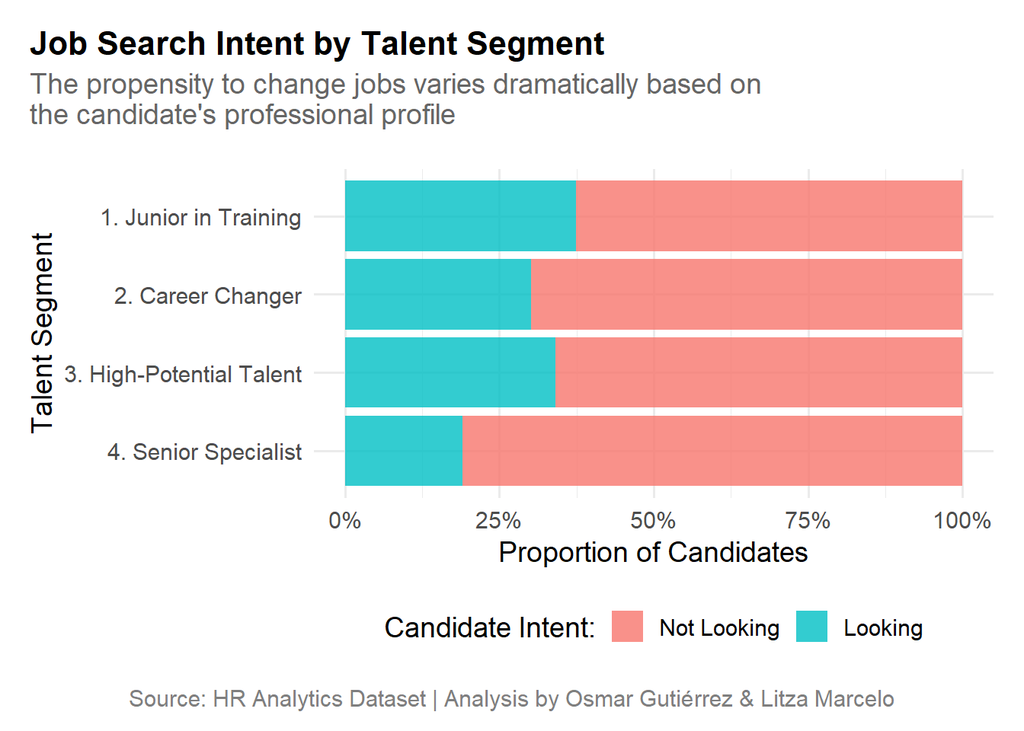

## The solution: A Three-Speed Talent Strategy

This insight enables us to transition from a one-size-fits-all approach to a precise, data-driven strategy. We developed a predictive model with a validated area under the curve **(AUC) of 0.777,** indicating good predictive power, to automate this segmentation and enable a three-speed approach to recruitment:

1. **The Volume Engine is designed for juniors and career changers**. This uses an efficient, high-volume process to attract candidates who are actively looking for training and opportunity.
2. **High-Potential Magnet (for relevant young talent):** Attract this key group with challenging projects, clear career paths, and specialized development, not just salary.
3. **Surgical Hunting (for senior specialists):** Engage this passive group with highly personalized, strategic outreach focused on leadership, impact, and mission.

Understanding *who* is looking and *why* allows us to tailor our message and strategy, dramatically increasing recruitment efficiency and attracting the right talent for the right role.

#### Demostración de la Herramienta Interactiva

A continuación se muestra el funcionamiento de la herramienta de decisión. El video demuestra cómo evaluar el perfil de un candidato en tiempo real.

[video not shown]